# Chennai Water Crisis Analysis

This is an analysis of the water reservoirs in Chennai and the rainfall in the city from 2004 to 2019. It studies water levels of four major reservoirs of the city that supplies water to the populace. The data is being taken from 'Chennai Metropolitan Water Supply & Sewage Board'.

[figure not shown]

### About Chennai City:

Chennai (/ˈtʃɛnnaɪ/; also known as Madras /məˈdrɑːs/ or /-ˈdræs/, the official name until 1996) is the capital of the Indian state of Tamil Nadu. Located on the Coromandel Coast off the Bay of Bengal, it is the biggest cultural, economic and educational centre of south India. According to the 2011 Indian census, it is the sixth-most populous city and fourth-most populous urban agglomeration in India. The city together with the adjoining regions constitute the Chennai Metropolitan Area, which is the 36th-largest urban area by population in the world. Chennai is among the most-visited Indian cities by foreign tourists. It was ranked the 43rd-most visited city in the world for the year 2015. The Quality of Living Survey rated Chennai as the safest city in India. Chennai attracts 45 percent of health tourists visiting India, and 30 to 40 percent of domestic health tourists.As such, it is termed "India's health capital". As a growing metropolitan city in a developing country, Chennai confronts substantial pollution and other logistical and socio-economic problems.

#### Geographic Value of the city:

Chennai is located on the south–eastern coast of India in the north–eastern part of Tamil Nadu on a flat coastal plain known as the Eastern Coastal Plains. Its average elevation is around 6.7 metres (22 ft),and its highest point is 60 m (200 ft).Chennai is 2,184 kilometres (1,357 mi) south of Delhi, 1,337 kilometres (831 mi) southeast of Mumbai, and 345 kilometres (214 mi) east of Bangalore by road. Two major rivers flow through Chennai, the Cooum River (or Koovam) through the centre and the Adyar River to the south. A third river, the Kortalaiyar, travels through the northern fringes of the city before draining into the Bay of Bengal, at Ennore. The estuary of this river is heavily polluted with effluents released by the industries in the region. Adyar and Cooum rivers are heavily polluted with effluents and waste from domestic and commercial sources, the Coumm being so heavily polluted it is regarded as the city's eyesore. A protected estuary on the Adyar forms a natural habitat for several species of birds and animals. The Buckingham Canal, 4 km (2.5 mi) inland, runs parallel to the coast, linking the two rivers. The Otteri Nullah, an east–west stream, runs through north Chennai and meets the Buckingham Canal at Basin Bridge. Several lakes of varying size are located on the western fringes of the city. Some areas of the city have the problem of excess iron content in groundwater.

[figure not shown]

# Data Analysis

There are basically 4 major reservoirs in chennai that supply water to the entire population of the country. The analysis done below deals with finding out the trends in the water levels of these reservoirs. The reservoirs are drying up and the people are dying out of thirst, the farmers are committing sucides as they're failing to produce productive yields. Water crisis in Chennai is a major concern and has been globally known.

[figure not shown]

```python
import pandas as pd
import numpy as np
from matplotlib import pyplot as plt
%matplotlib inline
import seaborn as sns
%config InlineBackend.figure_format = 'retina'
sns.set()
```

```python
df1=pd.read_csv('chennai_reservoir_levels.csv')
```

```python
print(df1.head())
```

```
         Date  POONDI  CHOLAVARAM  REDHILLS  CHEMBARAMBAKKAM
0  01-01-2004     3.9         0.0     268.0              0.0
1  02-01-2004     3.9         0.0     268.0              0.0
2  03-01-2004     3.9         0.0     267.0              0.0
3  04-01-2004     3.9         0.0     267.0              0.0
4  05-01-2004     3.8         0.0     267.0              0.0
```

```python
p=pd.Series(df1['POONDI'])
c=pd.Series(df1['CHOLAVARAM'])
r=pd.Series(df1['REDHILLS'])
ck=pd.Series(df1['CHEMBARAMBAKKAM'])
```

## Pie chart to divide the reservoir with respect to water level in past 5 years

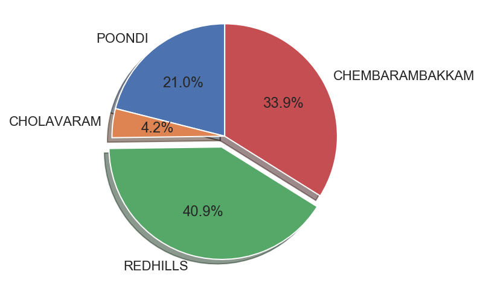

```python
res=[p[3650:].mean(),c[3650:].mean(),r[3650:].mean(),ck[3650:].mean()]
labels = ['POONDI', 'CHOLAVARAM', 'REDHILLS', 'CHEMBARAMBAKKAM']
explode = (0, 0, 0.1, 0)  # only "explode" the 2nd slice (i.e. 'Hogs')

fig1, ax1 = plt.subplots()
ax1.pie(res, explode=explode, labels=labels, autopct='%1.1f%%',
        shadow=True, startangle=90)
ax1.axis('equal')  # Equal aspect ratio ensures that pie is drawn as a circle.

plt.show()
```

The pie chart above shows the contribution of each reservoir in past 5 years for serving the population of the city. It is observed that Redhills and Chembarambakkam are the two reservoirs that conntribute majorly in serving the populace with water. These two reservoir hold approximately 75% of the water in the city.

```python
from tabulate import tabulate
print(tabulate([[labels[0],res[0]],[labels[1],res[1]],[labels[2],res[2]],[labels[3],res[3]]], headers=['Reservoir', 'Water Level']))
```

```
Reservoir          Water Level
---------------  -------------
POONDI                 559.765
CHOLAVARAM             110.82
REDHILLS              1087.4
CHEMBARAMBAKKAM        901.736
```

#### Average Water Level of these reservoirs in past 5 years is given above

# Trends in Water level in the reservoir from 2004 to 2019 is given below for all 4 reservoirs.

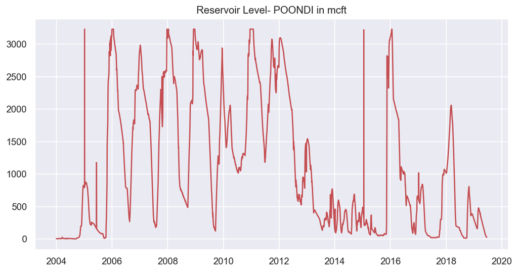

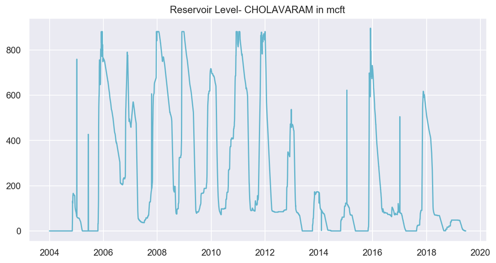

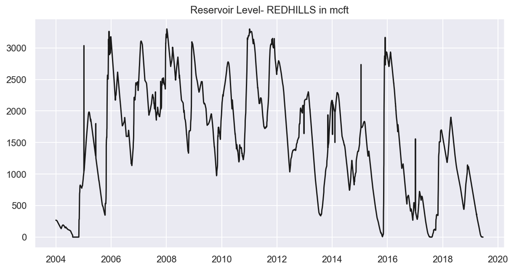

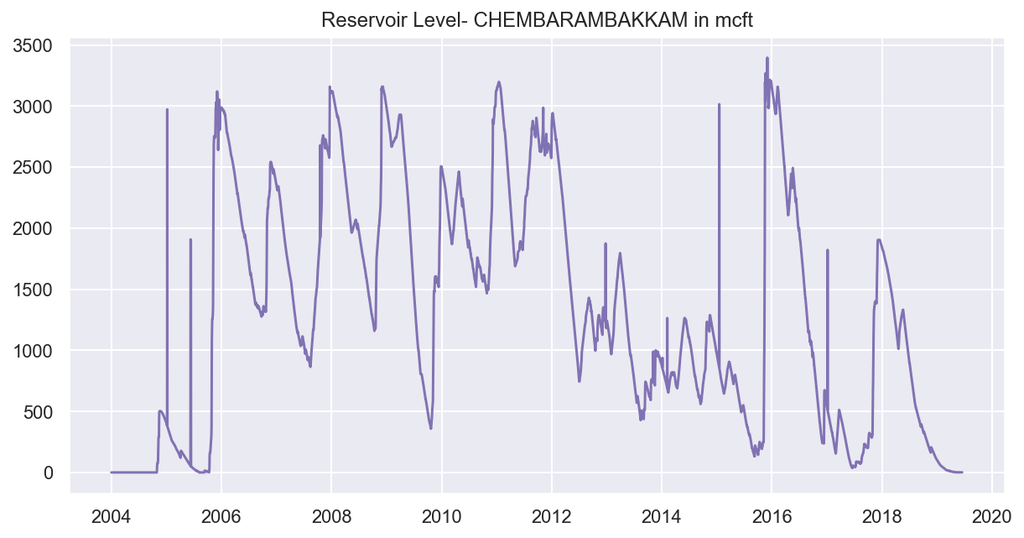

```python
df1['Date']=pd.to_datetime(df1["Date"], format='%d-%m-%Y')

plt.figure(figsize=(10,5))
plt.plot(df1['Date'],p,"r-")
plt.title('Reservoir Level- POONDI in mcft')
plt.show()

plt.figure(figsize=(10,5))
plt.plot(df1['Date'],c,"c-")
plt.title('Reservoir Level- CHOLAVARAM in mcft')
plt.show()

plt.figure(figsize=(10,5))
plt.plot(df1['Date'],r,"k-")
plt.title('Reservoir Level- REDHILLS in mcft')
plt.show()

plt.figure(figsize=(10,5))
plt.plot(df1['Date'],ck,"m-")
plt.title('Reservoir Level- CHEMBARAMBAKKAM in mcft')

plt.show()
```

## Average water level in each year is being shown as a bar graph below:

The average reservoir level from january to december is being calculated and is being bar graphed against the year. A trend can be seen where the water level seem to vary very little in the begining but it can be seen that the water level is being decreasing each year as we approach 2019 i.e. the present year.

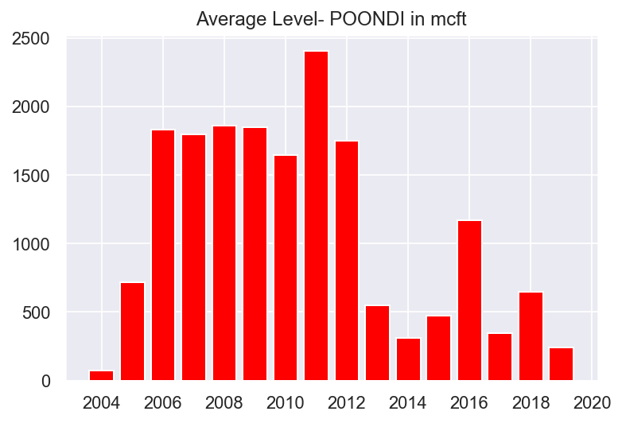

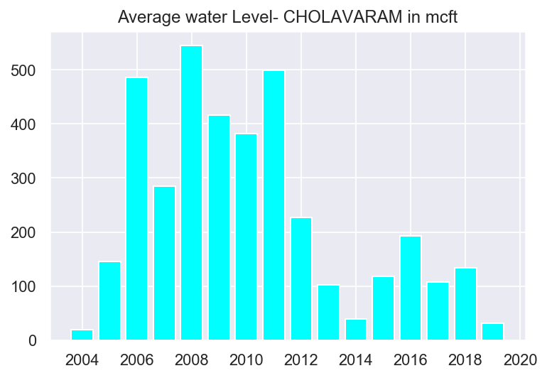

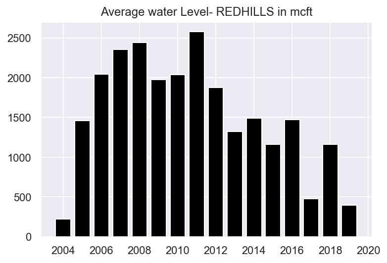

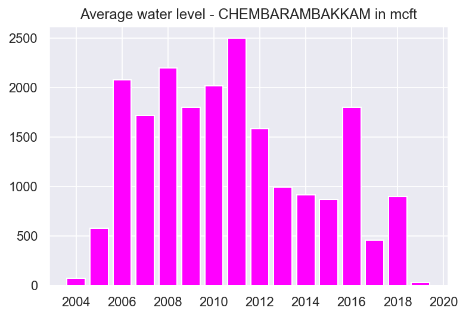

```python
dt=df1['Date']
Av_p=[]
Av_c=[]
Av_r=[]
Av_ck=[]
Yr=[]

for i in range(0,16):
    t=p[(i*365):(i+1)*365]
    Av_p.append(t.mean())
    t.drop(t.index, inplace=True)

    t=c[(i*365):(i+1)*365]
    Av_c.append(t.mean())
    t.drop(t.index, inplace=True)

    t=r[(i*365):(i+1)*365]
    Av_r.append(t.mean())
    t.drop(t.index, inplace=True)

    t=ck[(i*365):(i+1)*365]
    Av_ck.append(t.mean())
    t.drop(t.index, inplace=True)

    Yr.append(i+2004)
plt.bar(Yr,Av_p, color="red")
plt.grid(True, color="white", alpha=0.9)
plt.title('Average Level- POONDI in mcft')
plt.show()

plt.bar(Yr,Av_c, color="cyan")
plt.grid(True, color="white", alpha=0.9)
plt.title('Average water Level- CHOLAVARAM in mcft')
plt.show()

plt.bar(Yr,Av_r, color="black")
plt.grid(True, color="white", alpha=0.9)
plt.title('Average water Level- REDHILLS in mcft')
plt.show()

plt.bar(Yr,Av_ck, color="magenta")
plt.grid(True, color="white", alpha=0.9)
plt.title('Average water level - CHEMBARAMBAKKAM in mcft')
plt.show()
```

## Don't believe the data? Check it yourself:

The image given below shows the satelite image of one of the chennai water reservoir a few years ago and the current image alongside to have a comparison.

[figure not shown]

### Isn't it true what they say? 'Data' never lies!!

# Analysis of Rainfall

“The city has neglected all its water bodies and efforts to improve and recharge in the past decade,” said Sunita Narain, director general of the New Delhi-based Centre for Science and Environment. “Water crisis will be here to stay if we don’t understand the need to save every drop of water and rain.”

Chennai received the lowest rainfall in 15 years in 2018. The poor rainfall didn’t stop indiscriminate use of water from the city’s four reservoirs, which has contributed to a crunch this year, said Jyoti Sharma, who heads a non-profit working to conserve water. The city’s reservoirs have less than 1% of capacity as on Monday, that compares with 20% a year earlier, according to data on the Chennai Metropolitan Water Supply & Sewerage Board.

[figure not shown]

```python
df2=pd.read_csv('chennai_reservoir_rainfall.csv')
```

```python
df2.head()
```

|  | Date | POONDI | CHOLAVARAM | REDHILLS | CHEMBARAMBAKKAM |
| --- | --- | --- | --- | --- | --- |
| 0 | 01-01-2004 | 0.0 | 0.0 | 0.0 | 0.0 |
| 1 | 02-01-2004 | 0.0 | 0.0 | 0.0 | 0.0 |
| 2 | 03-01-2004 | 0.0 | 0.0 | 0.0 | 0.0 |
| 3 | 04-01-2004 | 0.0 | 0.0 | 0.0 | 0.0 |
| 4 | 05-01-2004 | 0.0 | 0.0 | 0.0 | 0.0 |

```python
pr=pd.Series(df2['POONDI'])
cr=pd.Series(df2['CHOLAVARAM'])
rr=pd.Series(df2['REDHILLS'])
ckr=pd.Series(df2['CHEMBARAMBAKKAM'])
```

[figure not shown]

[figure not shown]

[figure not shown]

[figure not shown]

```python
df2['Date']=pd.to_datetime(df1["Date"], format='%d-%m-%Y')

plt.figure(figsize=(10,5))
plt.plot(df2['Date'],p,"r-")
plt.title('Rainfall in POONDI in mm')
plt.show()

plt.figure(figsize=(10,5))
plt.plot(df2['Date'],c,"c-")
plt.title('Rainfall in CHOLAVARAM in mm')
plt.show()

plt.figure(figsize=(10,5))
plt.plot(df2['Date'],r,"k-")
plt.title('Rainfall in REDHILLS in mm')
plt.show()

plt.figure(figsize=(10,5))
plt.plot(df2['Date'],ck,"m-")
plt.title('Rainfall in CHEMBARAMBAKKAM in mm')

plt.show()
```

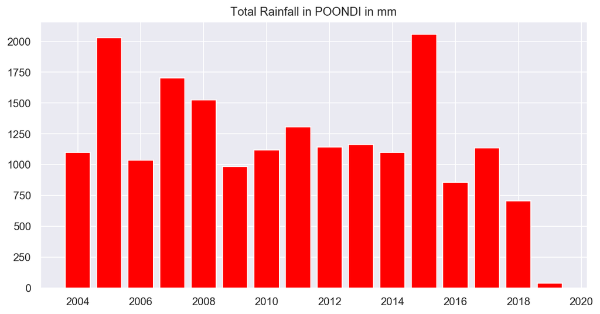

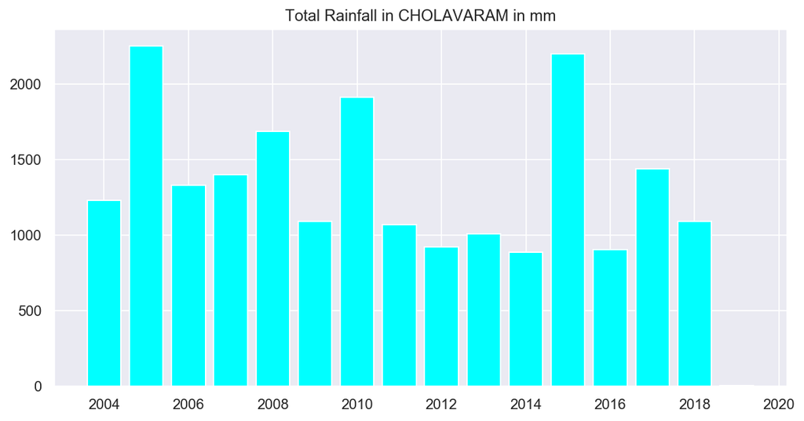

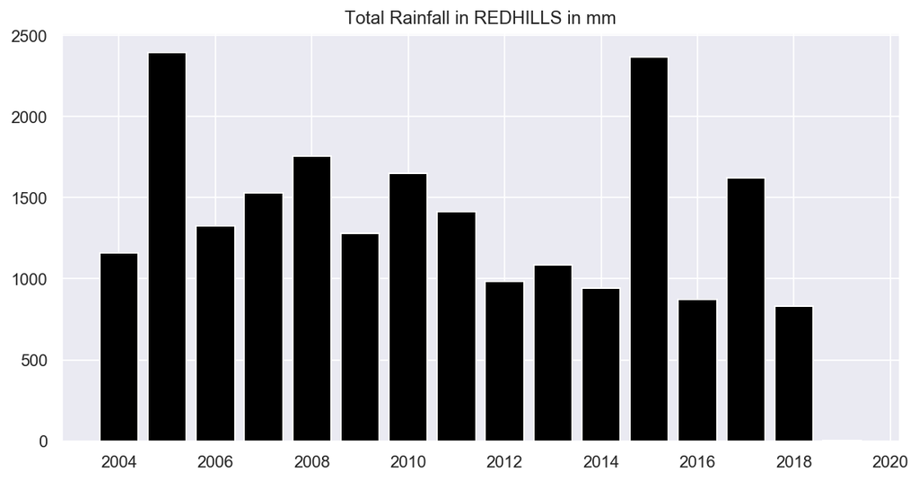

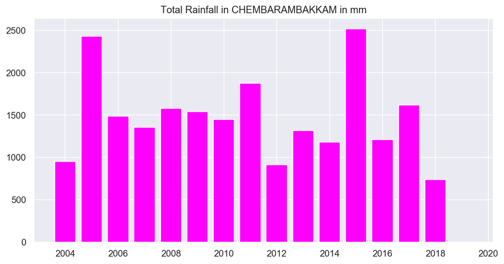

```python
dt=df2['Date']
Av_pr=[]
Av_cr=[]
Av_rr=[]
Av_ckr=[]
for i in range(0,16):
    t=pr[(i*365):(i+1)*365]
    Av_pr.append(t.sum())
    t.drop(t.index, inplace=True)

    t=cr[(i*365):(i+1)*365]
    Av_cr.append(t.sum())
    t.drop(t.index, inplace=True)

    t=rr[(i*365):(i+1)*365]
    Av_rr.append(t.sum())
    t.drop(t.index, inplace=True)

    t=ckr[(i*365):(i+1)*365]
    Av_ckr.append(t.sum())
    t.drop(t.index, inplace=True)

plt.figure(figsize=(10,5))
plt.bar(Yr,Av_pr, color="red")
plt.grid(True, color="white", alpha=0.9)
plt.title('Total Rainfall in POONDI in mm')
plt.show()

plt.figure(figsize=(10,5))
plt.bar(Yr,Av_cr, color="cyan")
plt.grid(True, color="white", alpha=0.9)
plt.title('Total Rainfall in CHOLAVARAM in mm')
plt.show()

plt.figure(figsize=(10,5))
plt.bar(Yr,Av_rr, color="black")
plt.grid(True, color="white", alpha=0.9)
plt.title('Total Rainfall in REDHILLS in mm')
plt.show()

plt.figure(figsize=(10,5))
plt.bar(Yr,Av_ckr, color="magenta")
plt.grid(True, color="white", alpha=0.9)
plt.title('Total Rainfall in CHEMBARAMBAKKAM in mm')
plt.show()
```

## Decrease in total Rainfall:

The ground water level is therefore decreasing day by day even though the rainfall hasn't yet decreased drastically. The city is becoming more and more populated and the problem of water scarcity is increasing exponentially.

Here, I end my analysis with this only one statement:

### "Only rain can save this Chennai."